# Precipitation Analysis

By: Alex Bans

February 04, 2023

## Introduction

Station 20, the USGS rain gauge is located at 1333 NW Eastman Parkway. As of the date of the compilation of this document there have been over 210639 hourly precipitation measurements and 1936 storm events recorded since its installation in 1997.

## Results

### Annual Breakdown

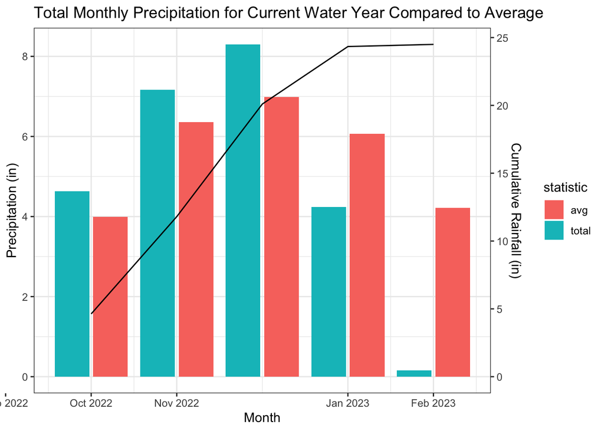

### Storm Breakdown

[output not shown]

### Breakdown by Water Year

It has rained 24.5 inches this water year. which is less than the average of 43 inches.

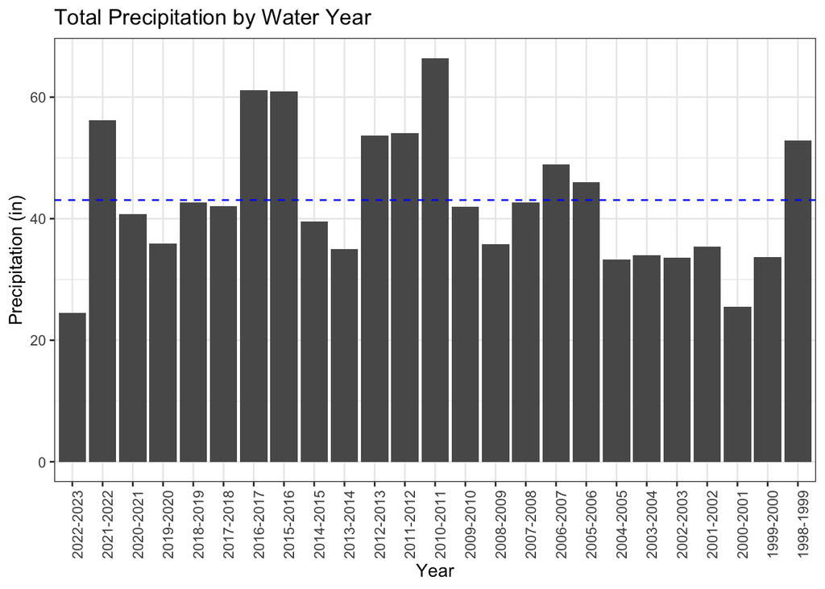

## Background

This project was written in R with the assistance of the TidyVerse, Lubridate, Zoo, Plotly, Here, and R Markdown packages, as well as several custom written functions to parse water year and storm data from the precipitation data.

Data was read directly from the Web processed, parsed for relevant dates and events, summary data aggregated, and then graphed before being compiled directly into a HTML document.

Storm events were defined as having at least 0.02 inches of rainfall and having at least 12 hours of separation between each event.

## Future Ideas

There are several ideas that may or may not be incorporated in this report. Firstly, I want to automate the compiling and distribution of this report at the end of the water year, every September 30th. Another thing I would be interested in doing is determining more interesting and relevant statistics in regards to the storm events that have occurred in the water year, such as return intervals (ex. 1 in 100 year storms). Utilizing the other rain gauges in the network could be used for spatial analysis. Finally, a useful potential update would be to incorporate other interesting environmental metrics such as snow events, temperature, air quality, and combined sewer overflow (CSO) events. The separation of storm events can also be useful for storm water runoff modeling.